# Deep Dive #1

## Part 1: Scale Invariant Equations

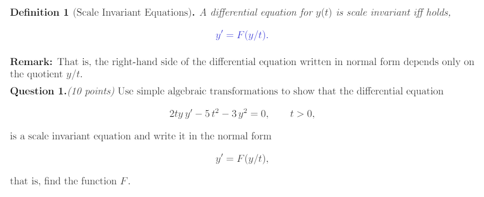

1. Show $2tyy'-5t^2-3y^2=0$ is scale invariant for $t>0$ by finding the funtion $F$ such that $y'=F(y/t)$

$$2tyy' = 5t^2+3y^2$$ $$y' = \dfrac{5t^2+3y^2}{2ty}$$ $$=\dfrac{3y}{2t} + \dfrac{5t}{2y} = \dfrac{3}{2} \dfrac{y}{t} + \dfrac{5}{2} \dfrac{t}{y} $$ $$\dfrac{3}{2} (y/t) + \dfrac{5}{2} (y/t)^{-1} =F(y/t)$$

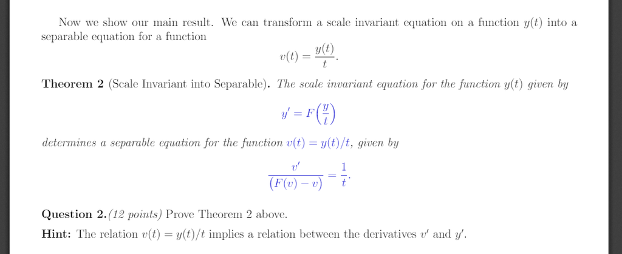

2. Pf. Show the separable equation is true

$v'=\dfrac{d}{dt} \dfrac{y(t)}{t} = \dfrac{t y'(t) - y(t)}{t^2}$

$F(v)-v = F(\frac{y}{t})-\frac{y}{t}$

Substitute these into the seperable equation

$$\dfrac{v'}{F(v)-v} = \dfrac{\frac{ty'(t)-y(t)}{t^2}}{F(\frac{y}{t})-\frac{y}{t}} $$ Substitute and simplify $$=\dfrac{ty'(t)-y(t)}{t^2(F(\frac{y}{t})-\frac{y}{t})}=\dfrac{(y'-\frac{y}{t})}{t(y'-\frac{y}{t})} = \dfrac{1}{t} $$ QED

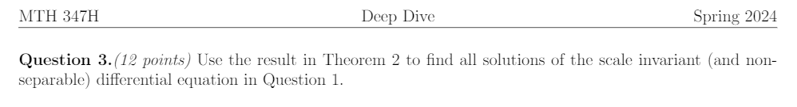

3. Close the loop

$y' = F(y/t) = \dfrac{3}{2} (y/t) + \dfrac{5}{2} (y/t)^{-1} = F(v)$

Since $y = tv$, then $y'=v+tv'$, which implies $$v + tv' = \frac{3}{2}v+\frac{5}{2}v^-1 $$ We rewrite and integrate it $$\dfrac{2v}{v^2+5}v'=\dfrac{1}{t} \implies \int \dfrac{2v}{v^2+5}v'dt =\int \dfrac{dt}{t} + c_0$$

We use $u = v^2 +5$ which implies $du = 2v v'$ and get something familiar from the textbook $$\int \dfrac{du}{u} = \int{dt}{t} +c_0 \implies \ln(u) = \ln(t)+c_0 \implies u = tc_1$$ where $c_1 = e^{c_0}$

## Part 2: Variation of parameters for linear equations

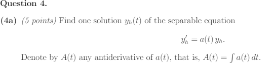

4. a)  
   Any solution would be $y_h(t)=ce^{A(t)}$, so I'll choose $y_h(t)=e^{A(t)}$

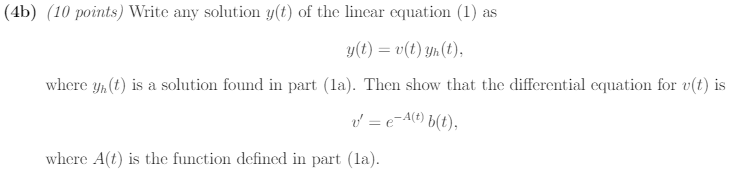

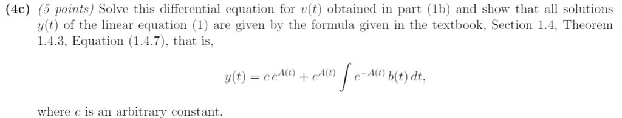

c)
Let's integrate v'(t) $$\int v' dt = \int e^{-A(t)}b(t)dt +c$$ Since $v(t)=\dfrac{y(t)}{e^{A(t)}}$ we get $$\int v' dt = v(t) = \dfrac{y(t)}{e^{A(t)}} =c+ \int e^{-A(t)}b(t)dt\implies y(t) = ce^{A(t)} + e^{A(t)}\int e^{-A(t)}b(t)dt$$

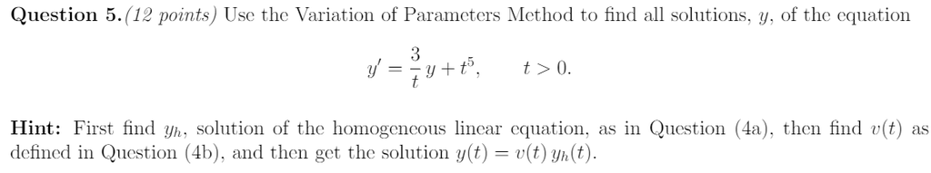

5. First we'll define $a(t)$ and $b(t)$

$$a(t)=\dfrac{3}{t} \implies A(t) = 3\ln(t)+c$$ $$b(t)=t^5$$

Now to the hint.

$$y(t)=v(t)y_h(t) \implies y'_h=a(t)y_h \implies y_h(t)=e^{A(t)}$$

This leads us to

$$y(t)=v(t)e^{A(t)}$$

All we need now is $v(t)$, and not in terms of $y$. From our result in (4b) and (4c) we have $$\int v' dt = v(t) = \dfrac{y(t)}{e^{A(t)}} =c+ \int e^{-A(t)}b(t)dt\implies y(t) = ce^{A(t)} + e^{A(t)}\int e^{-A(t)}b(t)dt$$

Lets fill in and integrate

$$y(t) = c_0e^{3\ln(t)+c_1} + e^{3\ln(t)+c_1}\int e^{-3\ln(t)-c_1}t^5dt$$ $$= c_0t^3e^{c_1}+t^3e^{c_1}\int\dfrac{t^2}{e^{c_1}}dt$$ Lets define $c_2=c_0e^{c_1}$ $$y(t)=c_2t^3 +\frac{t^6}{3}$$

6. The Bernoulli Equation

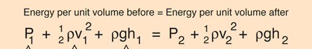

   from gsu hyperphysics

Wait. Not Daniel. $$y' = p(t)y +q(t)y^n$$

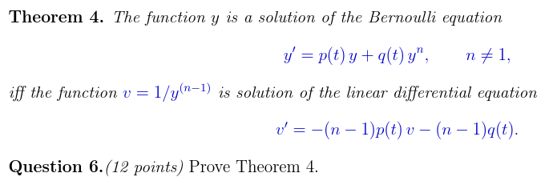

Okay I guess I'll just go and do that then. I'll be following the proof in the text book

We start by getting $v$ into the first equation

$$\dfrac{y'}{y^n}=\dfrac{p(t)y}{y^n}+q(t) = vp(t)+q(t) $$ From $v=\dfrac{1}{y^{(n-1)}}$ we have $$v'=(-n+1)*\dfrac{y'(t)}{y^n(t)} $$ The fraction on the RHS can be substituted with the equation we found earlier $$v'=(-n+1)*vp(t)+q(t)$$ which becomes the final equation of the proof $$v'=-(n-1)p(t)v-(n-1)q(t)$$

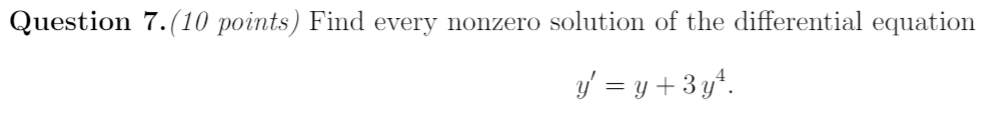

By doing a deep dive into the textbook, I find Theorem 1.5.2 which yields

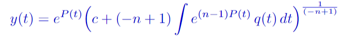

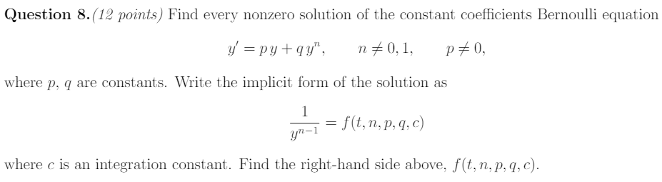

Since $\dfrac{1}{y^{n-1}}=v,$ lets start with the result we found in Theorem 4.

$v'=-(n-1)p(t)v-(n-1)q(t)$ is a linear equation, so I'll solve this using the solution we found in (4c).

$a(t)=-(n-1)p(t) \implies A(t)=-(n-1)P(t)$  
$b(t)=-(n-1)q(t)$

$$v(t) = ce^{-(n-1)P(t)}+e^{-(n-1)P(t)}\int e^{(n-1)P(t)}(-n+1)q(t)dt = f(t,n,p,q,c)$$

[figure not shown]